### 压力计算

#### Part 1: 简单例子

现在我们来用商业捕鱼为例子来描述一下计算过程。这是个较简单的例子，因为FIS没有子目标：

##### 压力背景:

有两种压力：环境和社会。“gamma” 值描述这两种压力在结合计算总压力时的相对负值。现在定为0.5，这样总压力是两种压力的平均值。

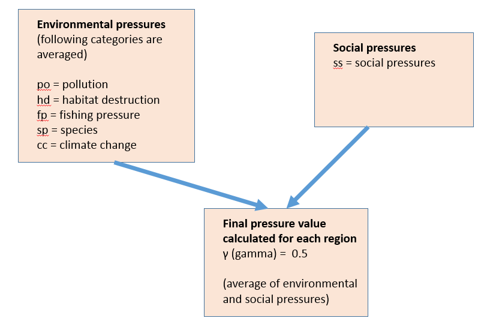

环境压力总共有五种类别：污染（po)， 生境破坏（hd)， 捕鱼压力(fp)， 物种（sp), 气候变暖（cc)。 每种类别又由几种压力层来构成。比如，气候变暖有四个压力层：海平面温度（cc_sst), 紫外线（cc_uv), 海平面上升（slr)，海洋酸性化（cc_acid)。

社会压力只有一个类别（ss)。 并只有一个压力层（ss_wgi)。

##### 压力计算的

工具箱里，有这样几个文件是用来计算压力的（ohicore/R)

*Calculate All*: This calculates status/trend, goal index, global scores, resilience, and pressures. Specifically, it calls the *CalculatePressuresAll* function. * *CalculatePressuresAll*: This aspect of the function loops through each goal and determines how to deal with it based on whether there are components and other variables. It calls: *CalculatePressuresScore* + *CalculatePressuresScore*: This does the primary calculations for pressures.

##### FIS 压力计算：

这是压力矩阵的头几栏，可能很小:

[figure not shown]

##### 环境压力

每个类别都是分别这样计算的 (po, fp, cc, sp, hd）。我们以 fp(捕鱼）为例

*STEP 1*: 调出举重和压力层的分数 这是FIS 目标， fp 类别的举重，每个省都有：

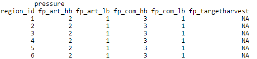

这是各省每个压力层的分数：

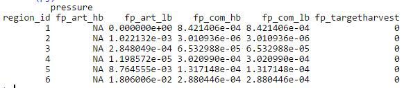

*STEP 2*: 举重 x 压力层分数

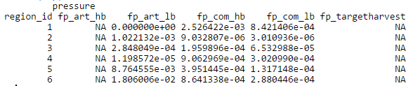

*STEP 3*: 每个省，*举重 x 压力层分数* 的总和

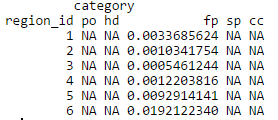

*STEP 4*: 重新调整分数 (根据 0-3 为规模界限，所以 0, 0.5, 1, 2, 3, 5; 变为: 0, 0.1666667, 0.3333333 0.6666667 1.0000000 1.0000000) 这样 所有值都为0-1. 为每个压力类别都重复STEP 1-4：

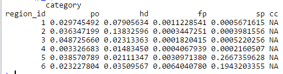

*STEP 5*: 现在，所有类别的得分被整合。我们用STEP4中得来的加权评分 。每个类别的举重是这个类别中压力层的举重的最大值：

加权平均后的 FIS 环境压力：

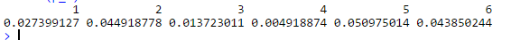

##### 社会压力

这只有一个社会压力类别，包括一个数据层。直接使用。如果有多个类别，和环境压力计算模式相同

*STEP 6*: 计算社会压力

##### 结和环境和社会压力

*STEP 7*: gamma=0.5, 所以FIS总和压力是社会和环境压力的平均值。